# Forecasting

### Exponential smoothing methods with trend

with the two smoothing parameters $\alpha$ and $\beta^*$.

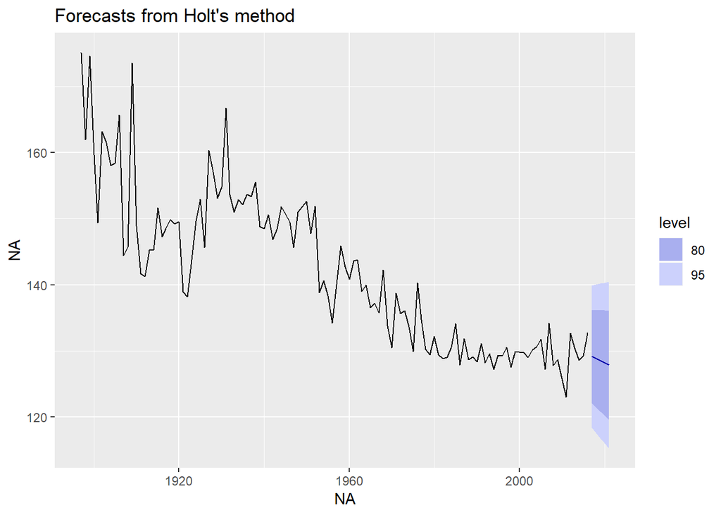

```r
# Holt's method in R
marathon %>%
  holt(h=5) %>%
  autoplot()
```

If $\phi = 1$, this is identical to Holt’s method.

```r
# Produce 10 year forecasts of austa using holt()
fcholt <- holt(austa, h=10, PI=FALSE)
fcholt_d <- holt(austa, h=10, damped = TRUE, PI =FALSE)

# Look at fitted model using summary()
summary(fcholt)
```

```
##
## Forecast method: Holt's method
##
## Model Information:
## Holt's method
##
## Call:
##  holt(y = austa, h = 10, PI = FALSE)
##
##   Smoothing parameters:
##     alpha = 0.9999
##     beta  = 0.0085
##
##   Initial states:
##     l = 0.656
##     b = 0.1706
##
##   sigma:  0.1952
##
##      AIC     AICc      BIC
## 17.14959 19.14959 25.06719
##
## Error measures:
##                      ME      RMSE       MAE       MPE     MAPE      MASE
## Training set 0.00372838 0.1840662 0.1611085 -1.222083 5.990319 0.7907078
##                   ACF1
## Training set 0.2457733
##
## Forecasts:
##      Point Forecast
## 2016       7.030683
## 2017       7.202446
## 2018       7.374209
## 2019       7.545972
## 2020       7.717736
## 2021       7.889499
## 2022       8.061262
## 2023       8.233025
## 2024       8.404788
## 2025       8.576552
```

```r
summary(fcholt_d)
```

```
##
## Forecast method: Damped Holt's method
##
## Model Information:
## Damped Holt's method
##
## Call:
##  holt(y = austa, h = 10, damped = TRUE, PI = FALSE)
##
##   Smoothing parameters:
##     alpha = 0.9999
##     beta  = 0.3722
##     phi   = 0.9155
##
##   Initial states:
##     l = 0.8185
##     b = 0.0097
##
##   sigma:  0.2084
##
##      AIC     AICc      BIC
## 22.70137 25.59792 32.20249
##
## Error measures:
##                      ME     RMSE       MAE      MPE     MAPE     MASE
## Training set 0.05346145 0.193374 0.1591405 1.970448 5.154104 0.781049
##                    ACF1
## Training set 0.05294818
##
## Forecasts:
##      Point Forecast
## 2016       7.175836
## 2017       7.465970
## 2018       7.731594
## 2019       7.974778
## 2020       8.197418
## 2021       8.401248
## 2022       8.587859
## 2023       8.758705
## 2024       8.915118
## 2025       9.058317
```

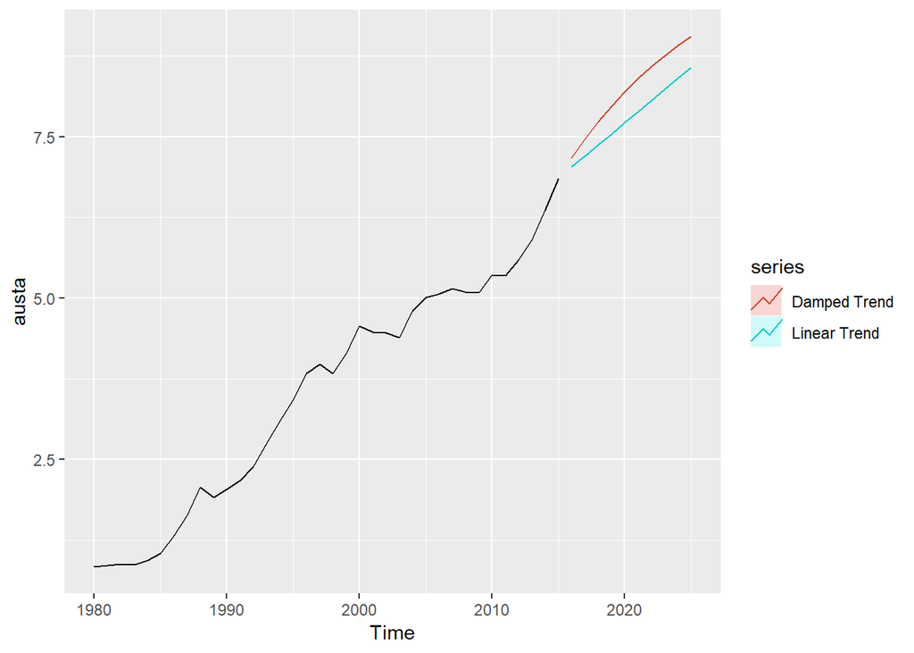

```r
# Plot the forecasts
autoplot(austa) +
  autolayer(fcholt, series="Linear Trend") +
  autolayer(fcholt_d, series="Damped Trend")
```

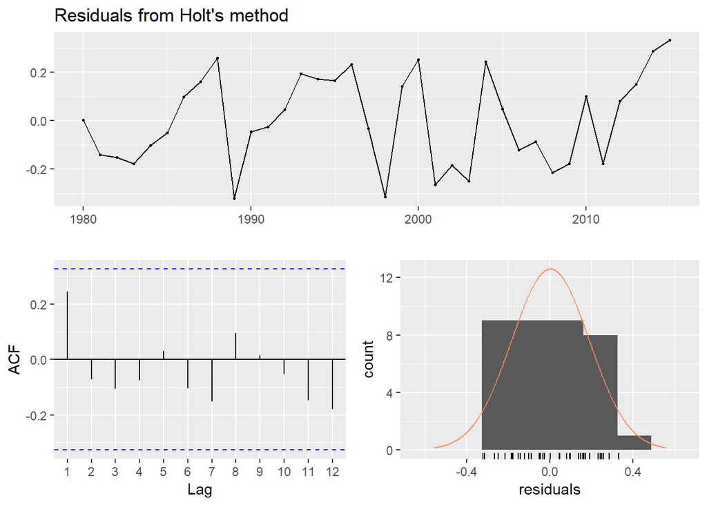

```
##
##  Ljung-Box test
##
## data:  Residuals from Holt's method
## Q* = 4.8886, df = 3.2, p-value = 0.2022
##
## Model df: 4.   Total lags used: 7.2
```

```r
# Check that the residuals look like white noise
checkresiduals(fcholt)
```

### Holt-Winter’s method with trend and seasonality

Additional seasonal component to Holt’s method.

$m=$ period of seasonality (e.g. 4 for quarterly data)

There is also a multiplicative version of Holt-Winter’s method, which is preferred in case where the seasonal variation increases with level of the series (greater variance). This is often the case.

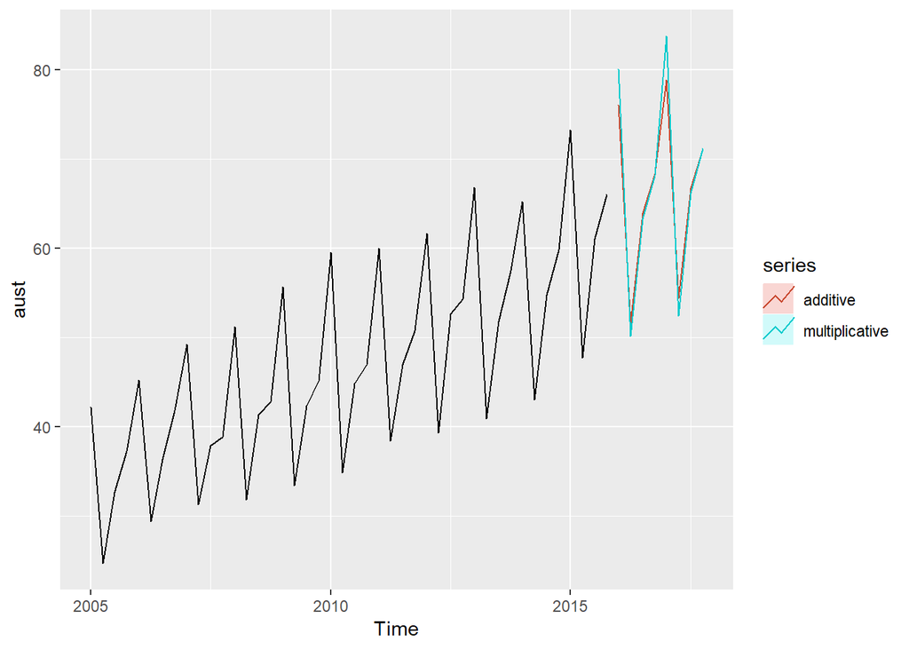

```r
aust <- window(austourists, start=2005)
fc1 <- hw(aust, seasonal="additive", PI=FALSE)
fc2 <- hw(aust, seasonal = "multiplicative", PI=FALSE)

autoplot(aust) +
  autolayer(fc1, series="additive") +
  autolayer(fc2, series="multiplicative")
```

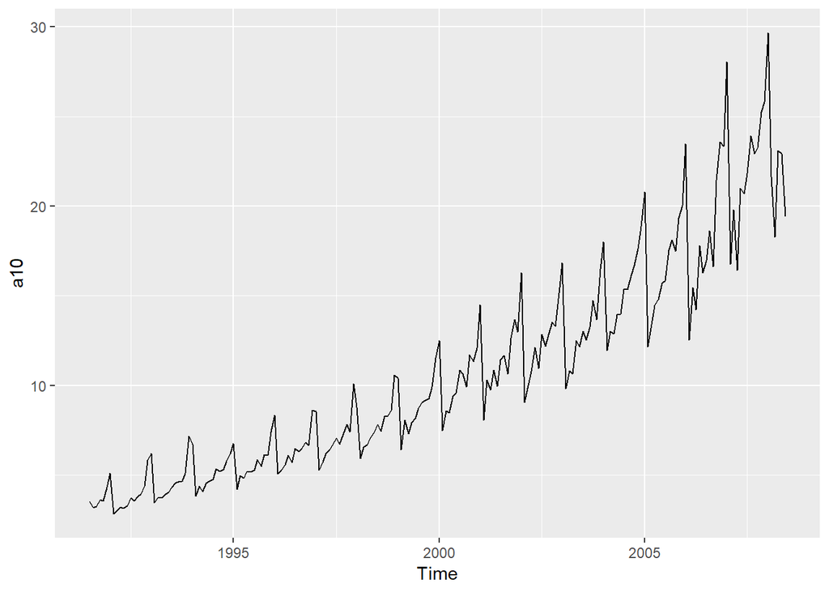

```r
# Plot the data
autoplot(a10)
```

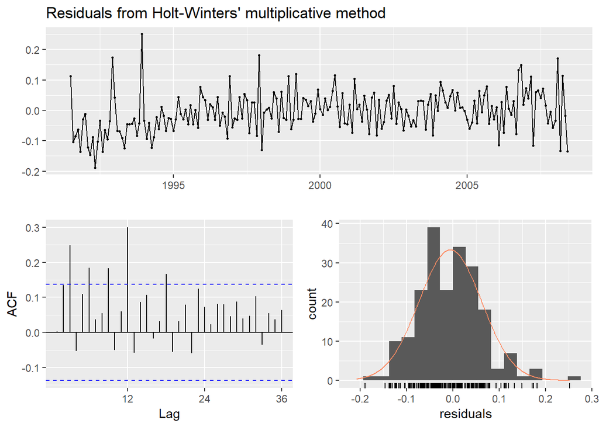

```
##
##  Ljung-Box test
##
## data:  Residuals from Holt-Winters' multiplicative method
## Q* = 75.764, df = 8, p-value = 3.467e-13
##
## Model df: 16.   Total lags used: 24
```

```r
# Produce 3 year forecasts
fc <- hw(a10, seasonal = "multiplicative", h = 36)

# Check if residuals look like white noise
checkresiduals(fc)
```

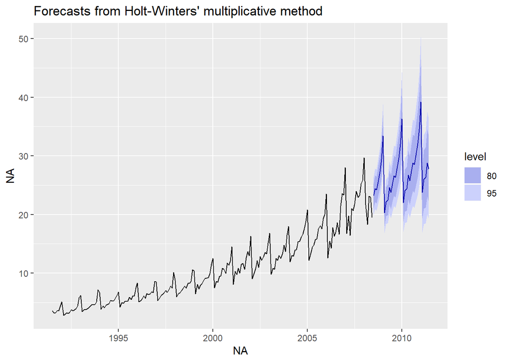

```r
whitenoise <- FALSE

# Plot forecasts
autoplot(fc)
```

```r
# Create training data with subset()
train <- subset(hyndsight, end = length(hyndsight) - (4*7))

# Holt-Winters additive forecasts as fchw
fchw <- hw(train, seasonal = "additive", h = (4*7))

# Seasonal naive forecasts as fcsn
fcsn <- snaive(train, 28)

# Find better forecasts with accuracy()
accuracy(fchw, hyndsight)
```

```
##                     ME     RMSE      MAE       MPE    MAPE      MASE
## Training set -3.976241 228.2440 165.0244 -2.407211 13.9955 0.7492131
## Test set     -3.999460 201.7656 152.9584 -3.218292 10.5558 0.6944332
##                   ACF1 Theil's U
## Training set 0.1900853        NA
## Test set     0.3013328 0.4868701
```

```r
accuracy(fcsn, hyndsight)
```

```
##                 ME     RMSE      MAE        MPE     MAPE      MASE
## Training set 10.50 310.3282 220.2636 -2.1239387 18.01077 1.0000000
## Test set      0.25 202.7610 160.4643 -0.6888732 10.25880 0.7285101
##                   ACF1 Theil's U
## Training set 0.4255730        NA
## Test set     0.3089795  0.450266
```

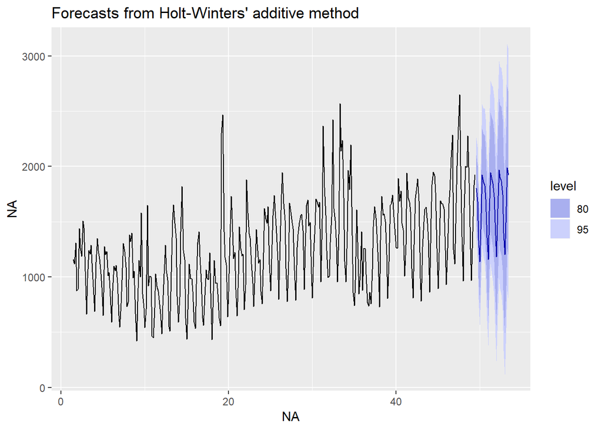

```r
# Plot the better forecasts
autoplot(fchw)
```

### State space models for exponential smoothing

Each exponential smoothing method can be written as an **innovations state space model**. In genereal, there are 18 possible state space models:

- Trend = {None, Adittive, Additive_dampened}
- Seasonal = {None, Additive, Multiplicative}

which result in 9 possible exponential smoothing methods and

- Error = {Addittive, Multiplicative}

leading to 18 possible state space models. These are called ETS models (Error, Trend, Seasonal). Parameters of ETS models can be estimated using **Maximum Likelihood Estimation**, which is the probability of the data arising from the specified model. For models with additive errors, this is equivalent to minimizing SSE. Choose the best model by minimizing a corrected version of Akaike’s Information Criterion (AIC_c). The function `ets()` does this internally yielding to the best model fit. This function gives you the best model without forecasting. Hence, it has to be handed to the forecasting function.

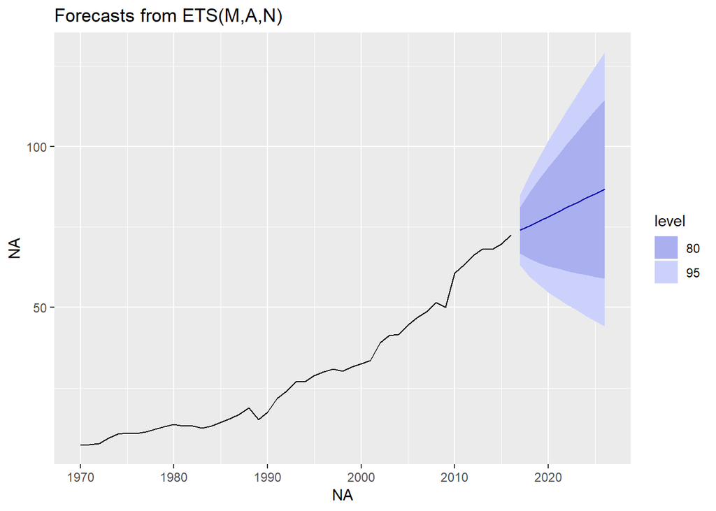

```r
# ETS model on ausair
ausair %>%
  ets() %>%
  forecast() %>%
  autoplot()
```

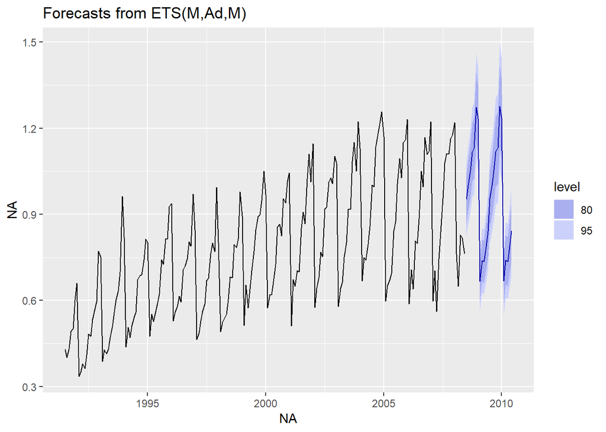

```r
h02 %>%
  ets() %>%
  forecast() %>%
  autoplot()
```

Type of model is chosen for you in the ets() function.

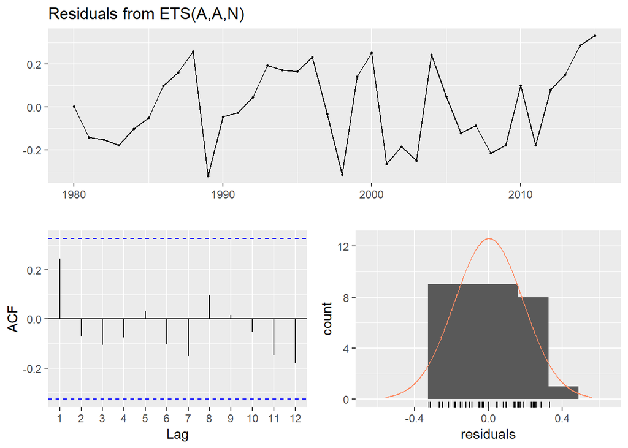

```
##
##  Ljung-Box test
##
## data:  Residuals from ETS(A,A,N)
## Q* = 4.8886, df = 3.2, p-value = 0.2022
##
## Model df: 4.   Total lags used: 7.2
```

```r
# Fit ETS model to austa in fitaus
fitaus <- ets(austa)

# Check residuals
checkresiduals(fitaus)
```

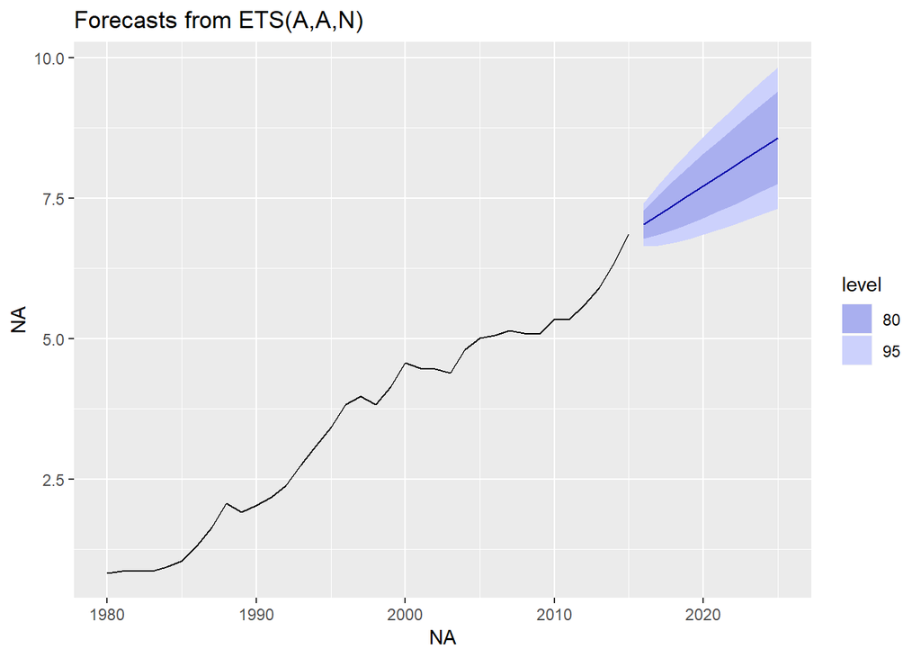

```r
# Plot forecasts
autoplot(forecast(fitaus))
```

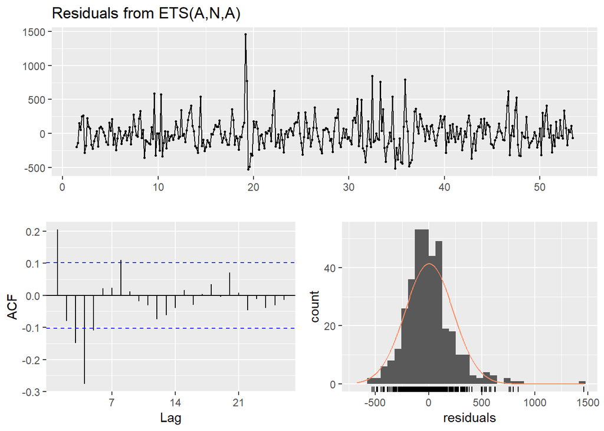

```
##
##  Ljung-Box test
##
## data:  Residuals from ETS(A,N,A)
## Q* = 68.616, df = 5, p-value = 1.988e-13
##
## Model df: 9.   Total lags used: 14
```

```r
# Repeat for hyndsight data in fiths
fiths <- ets(hyndsight)
checkresiduals(fiths)
```

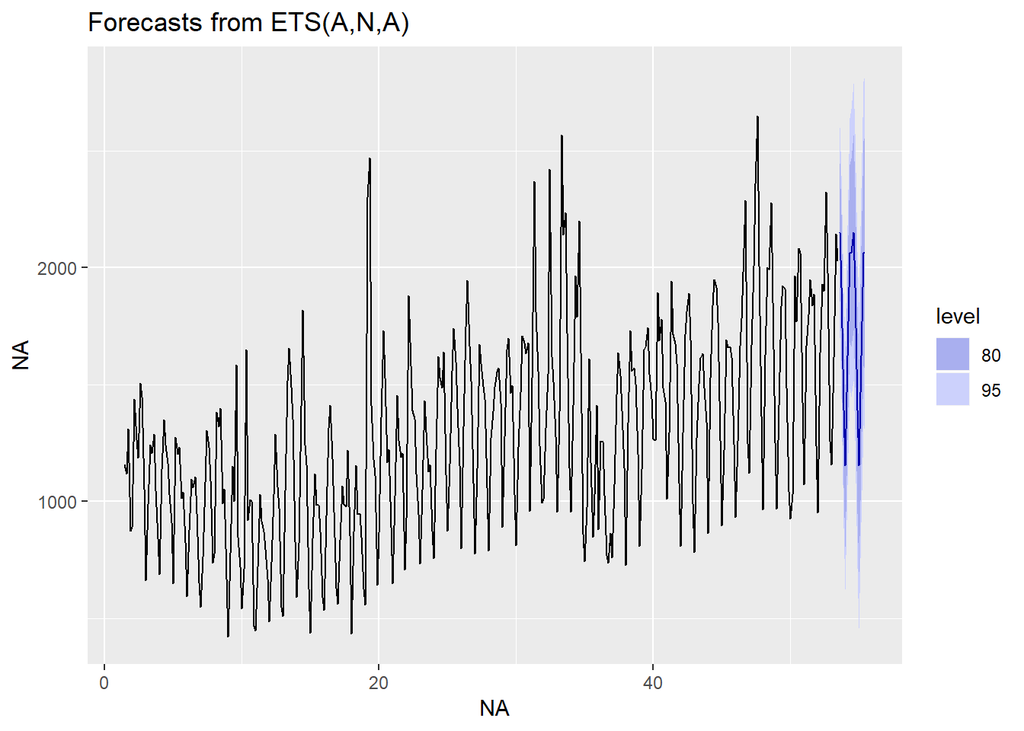

```r
autoplot(forecast(fiths))
```

The null hypothesis of independently distributed residuals can not be rejected for the first model but can be rejected for the second one. Hence, the residuals of the ETS model on `hyndsight` exhibts serial correlation.

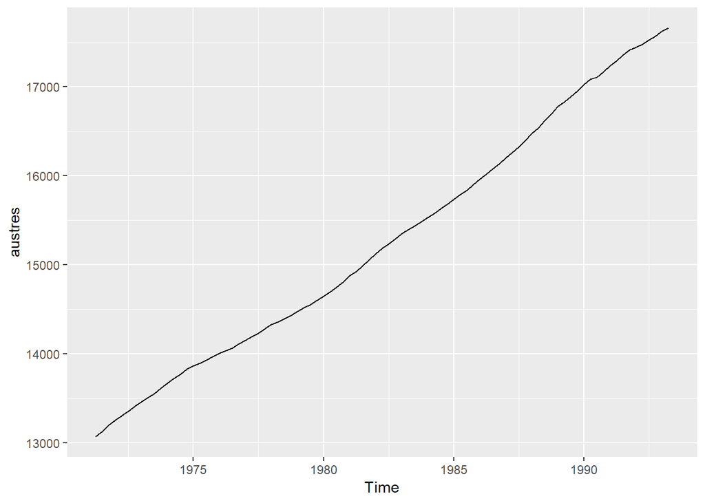

```r
autoplot(austres)
```

```r
# Function to return ETS forecasts
fets <- function(y, h) {
  forecast(ets(y), h = h)
}

# Apply tsCV() for both methods
e1 <- tsCV(austres, fets, h = 4)
e2 <- tsCV(austres, snaive, h = 4)

# Compute MSE of resulting errors (watch out for missing values)
mean(e1^2, na.rm=TRUE)
```

```
## [1] 1658.267
```

```r
mean(e2^2, na.rm=TRUE)
```

```
## [1] 44629.08
```

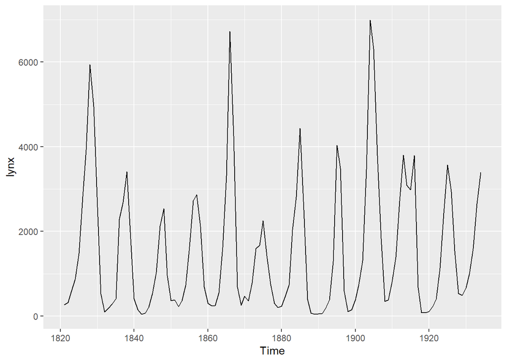

```r
# Plot the lynx series
autoplot(lynx)
```

```r
# Use ets() to model the lynx series
fit <- ets(lynx)

# Use summary() to look at model and parameters
summary(fit)
```

```
## ETS(M,N,N)
##
## Call:
##  ets(y = lynx)
##
##   Smoothing parameters:
##     alpha = 0.9999
##
##   Initial states:
##     l = 2372.8047
##
##   sigma:  0.9594
##
##      AIC     AICc      BIC
## 2058.138 2058.356 2066.346
##
## Training set error measures:
##                    ME     RMSE      MAE       MPE     MAPE     MASE
## Training set 8.975647 1198.452 842.0649 -52.12968 101.3686 1.013488
##                   ACF1
## Training set 0.3677583
```

```r
forecast(fit, 20)
```

```
##      Point Forecast         Lo 80       Hi 80        Lo 95       Hi 95
## 1935       3395.926     -779.2712    7571.123    -2989.487    9781.339
## 1936       3395.926    -3738.6446   10530.497    -7515.458   14307.310
## 1937       3395.926    -7335.8303   14127.682   -13016.879   19808.731
## 1938       3395.926   -12050.0589   18841.911   -20226.670   27018.522
## 1939       3395.926   -18411.0740   25202.926   -29955.002   36746.855
## 1940       3395.926   -27109.2707   33901.123   -43257.746   50049.599
## 1941       3395.926   -39081.0825   45872.935   -61567.053   68358.905
## 1942       3395.926   -55612.7533   62404.605   -86850.061   93641.913
## 1943       3395.926   -78479.4932   85271.345  -121821.722  128613.574
## 1944       3395.926  -110136.4415  116928.294  -170236.846  177028.699
## 1945       3395.926  -153982.3894  160774.242  -237293.437  244085.289
## 1946       3395.926  -214724.7304  221516.583  -330190.831  336982.683
## 1947       3395.926  -298884.8721  305676.724  -458902.661  465694.513
## 1948       3395.926  -415498.3931  422290.245  -637247.651  644039.503
## 1949       3395.926  -577085.1204  583876.973  -884373.225  891165.077
## 1950       3395.926  -800993.2803  807785.132 -1226811.204 1233603.057
## 1951       3395.926 -1111262.0338 1118053.886 -1701326.315 1708118.167
## 1952       3395.926 -1541202.3624 1547994.215 -2358863.305 2365655.157
## 1953       3395.926 -2136973.3913 2143765.243 -3270016.466 3276808.318
## 1954       3395.926 -2962538.1116 2969329.964 -4532608.750 4539400.603
```

## Ch. 4: Forecasting with ARIMA models

### Transformations for variance stabilization

If the data show increasing variation as the level of the series increases, then a transformation can be useful. Some common transformations to stabilize the vartiation are:

- Square root: $w_t = \sqrt{y_t}$
- Cube root: $w_t = \sqrt[3]{y_t}$
- Logarithm: $w_t = log(y_t)$
- Inverse: $w_t = -y_t^{-1}$

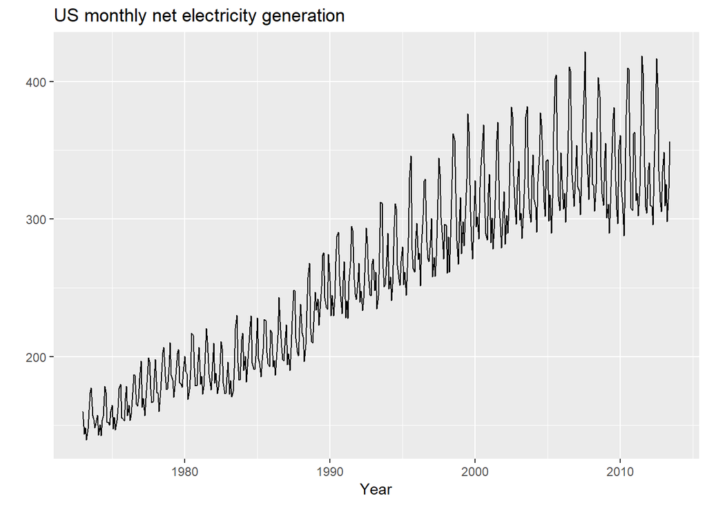

```r
autoplot(usmelec) +
  xlab("Year") +
  ylab("") +
  ggtitle("US monthly net electricity generation")
```

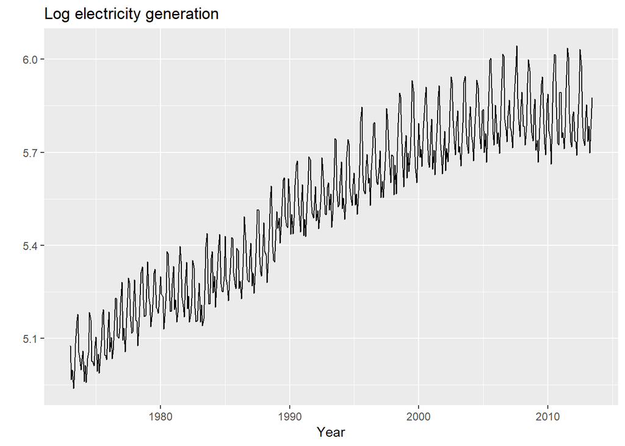

```r
autoplot(log(usmelec)) +
  xlab("Year") +
  ylab("") +
  ggtitle("Log electricity generation")
```

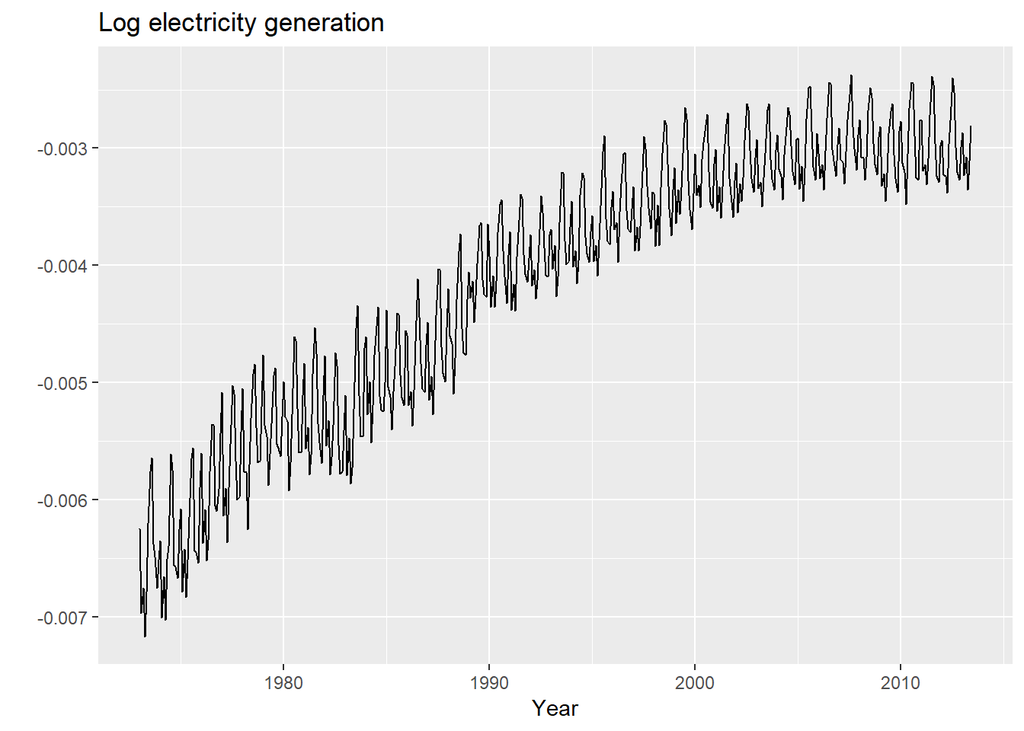

```r
autoplot(-1/usmelec) +
  xlab("Year") +
  ylab("") +
  ggtitle("Log electricity generation")
```

From the three transformations it seems as if we’d like to have something in between the `log`-transformation and the `inverse`-transformation. This is where the family of **Box-Cox transformations** come into play.

The **Box-Cox transformation** has a single parameter, $\lambda$, which controls how strong the transformation is:

- $w_t = log(y_t)$,if $\lambda = 0$
- $w_t = (y_t^\lambda - 1) / \lambda$, if $\lambda \neq 0$

This leads to the following transformations for different parameters of $lambda$.

- $\lambda = 1$: No substantive transformation (subtracting 1 from every observation)
- $\lambda = \frac{1}{2}$: Square root plus linear transformation
- $\lambda = \frac{1}{3}$: Cube root plus linear transformation

An estimate of lambda, which roughly balances the variance can be obtained using the `BoxCox.lambda()` function.

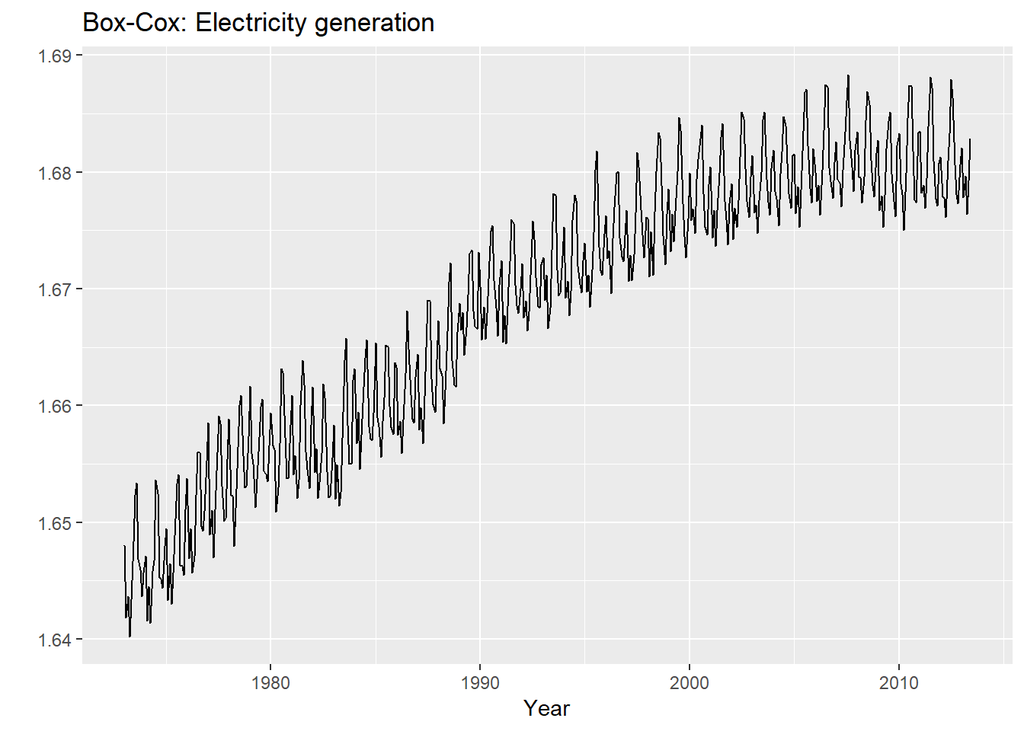

```r
# Estimate for lambda
lmd <- BoxCox.lambda(usmelec)

autoplot(BoxCox(usmelec, lmd)) +
  xlab("Year") +
  ylab("") +
  ggtitle("Box-Cox: Electricity generation")
```

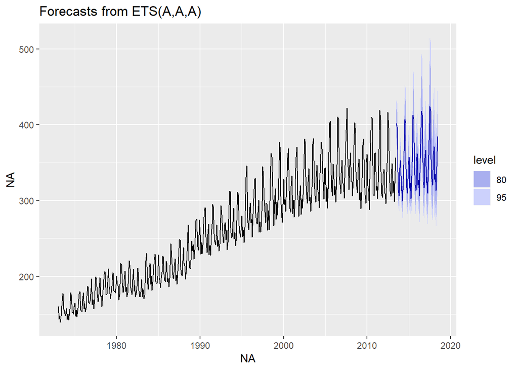

```r
# Apply this to ets function
usmelec %>%
  ets(lambda = lmd) %>%
  forecast(h = 60) %>%
  autoplot()
```

Here, R uses lmd for the Box-Cox transformation applies this to the chosen model and fits the model. Then, it passes this to the forecast function together with inforamtion on the transformation yielding in back-transformed forecasts for the series. Note that the ets function itself can take care of the varying fluctuations and that the combination of ets and Box-Cox transformation is not taht common.

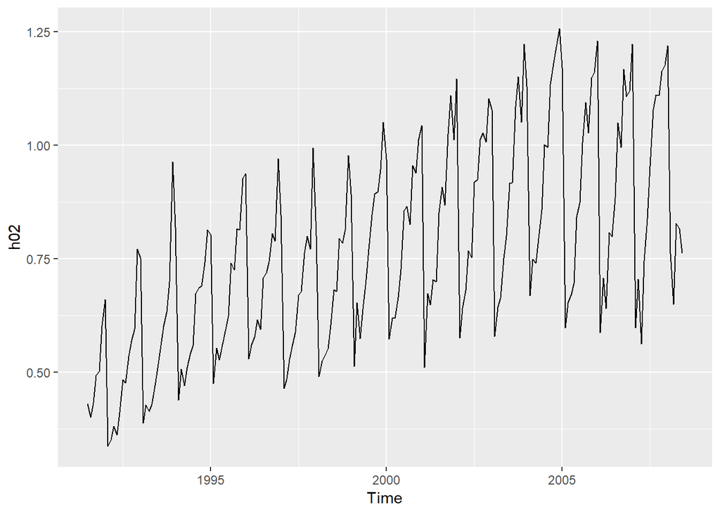

```r
# Plot the data
autoplot(h02)
```

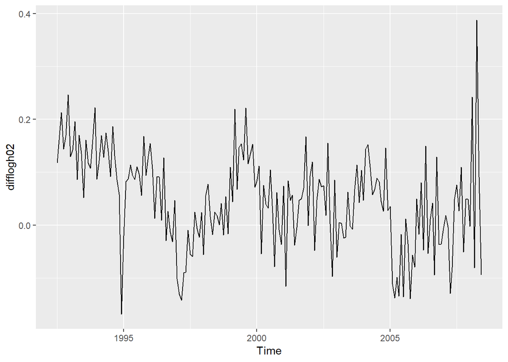

```r
# Take logs and seasonal differences of h02
difflogh02 <- diff(log(h02), lag = 12)

# Plot difflogh02
autoplot(difflogh02)
```

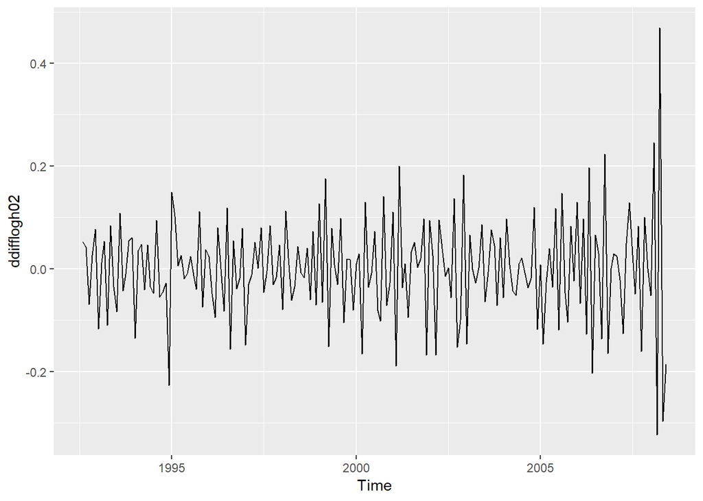

```r
# Take another difference and plot
ddifflogh02 <- diff(difflogh02)
autoplot(ddifflogh02)
```

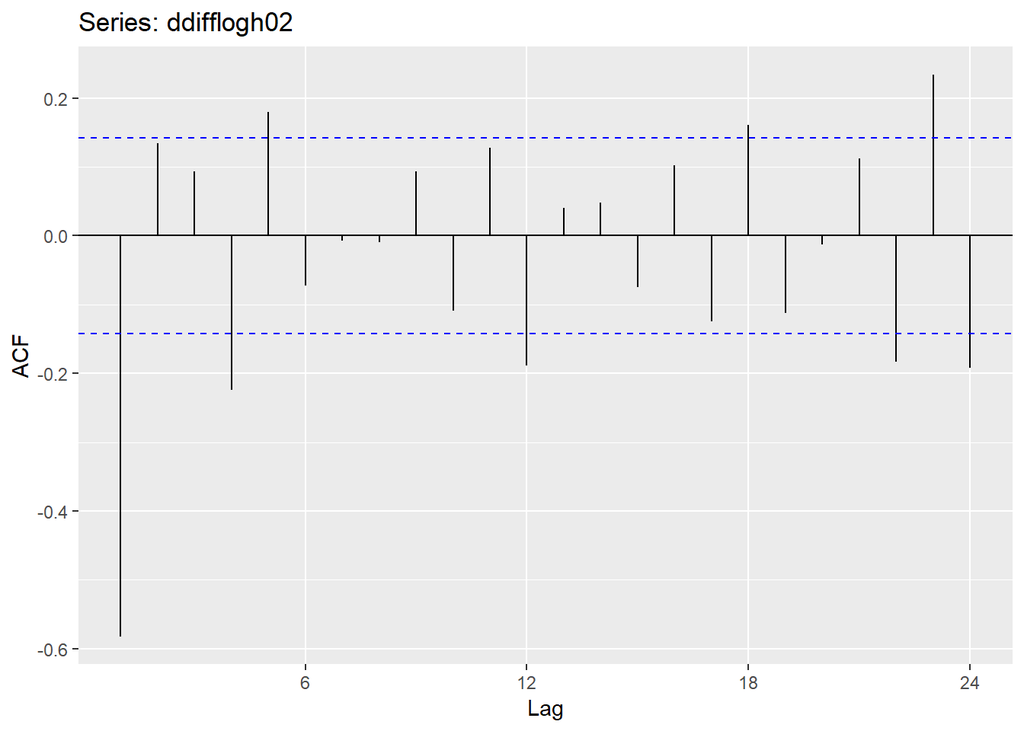

```r
# Plot ACF of ddifflogh02
ggAcf(ddifflogh02)
```

### ARIMA models

AR(p) models are multiple regression with p lagged observations as predictors and MA(q) models are multiple regression with q lagged errors as predictors. More information see Course 2 and Course 3. Together they are called ARMA(p,q) model as multiple regression with p lagged observations and q lagged errors as predictors. ARMA(p,q) works only with stationary data. That’s where the I in ARIMA comes into play. A model that is integrated of order d is an ARIMA(p,d,q) model.

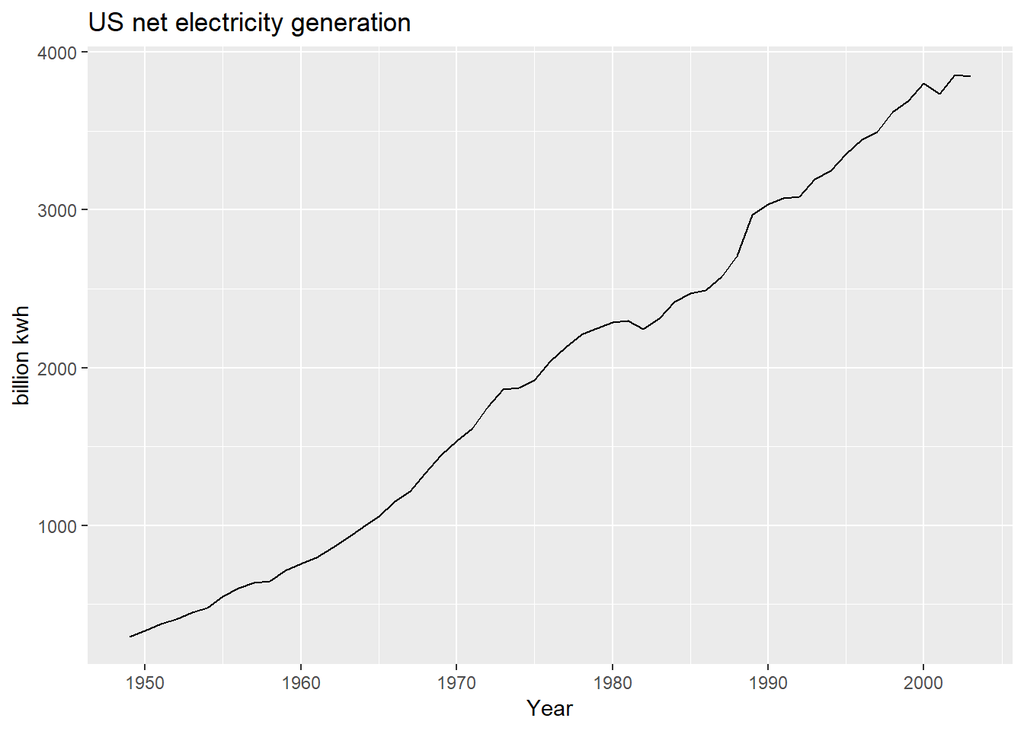

```r
autoplot(usnetelec) +
  xlab("Year") +
  ylab("billion kwh") +
  ggtitle("US net electricity generation")
```

The `auto.arima()`function chooses an ARIMA function on its own:

```r
fit <- auto.arima(usnetelec)
summary(fit)
```

```
## Series: usnetelec
## ARIMA(2,1,2) with drift
##
## Coefficients:
##           ar1      ar2     ma1     ma2    drift
##       -1.3032  -0.4332  1.5284  0.8340  66.1585
## s.e.   0.2122   0.2084  0.1417  0.1185   7.5595
##
## sigma^2 estimated as 2262:  log likelihood=-283.34
## AIC=578.67   AICc=580.46   BIC=590.61
##
## Training set error measures:
##                      ME     RMSE     MAE        MPE     MAPE      MASE
## Training set 0.04640184 44.89414 32.3328 -0.6177064 2.101204 0.4581279
##                    ACF1
## Training set 0.02249247
```

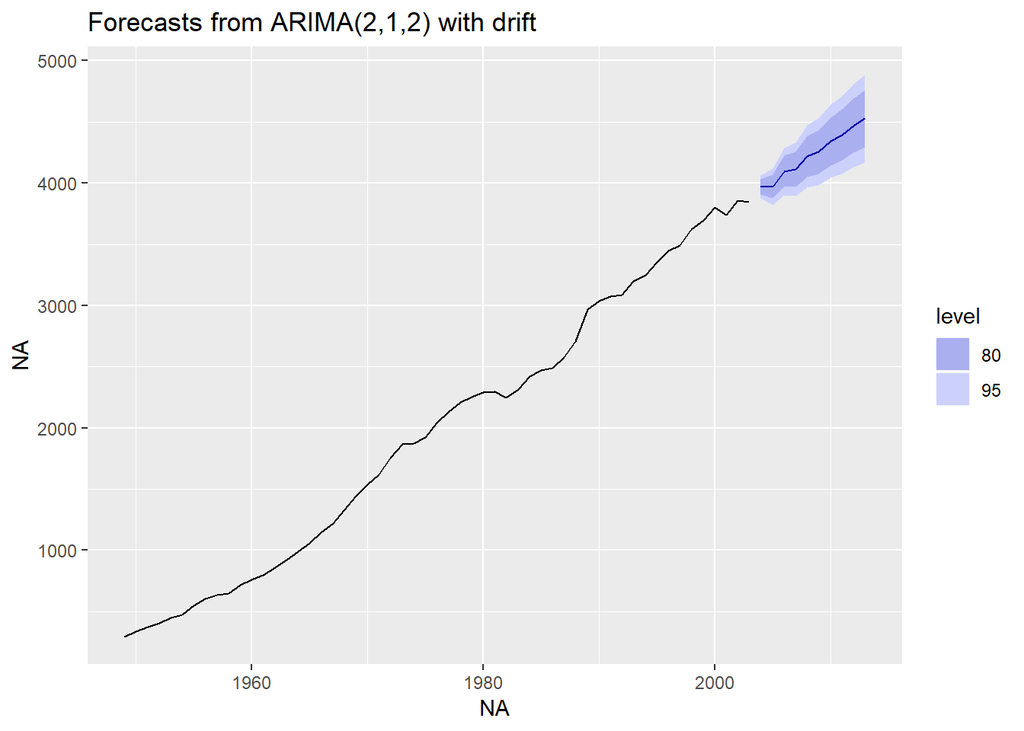

```r
fit %>%
  forecast(h=10) %>%
  autoplot()
```

The `auto.arima()` function selects the number of differences d via unit root tests and afterwards select p and q by minimizin AICc. Parameters are estimated using maximum likelihood estimation.

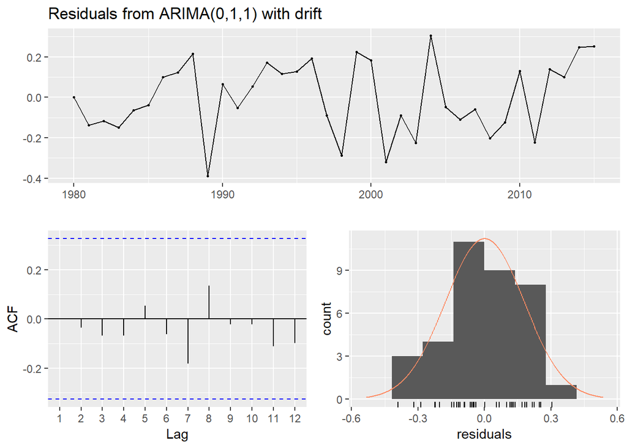

```
##
##  Ljung-Box test
##
## data:  Residuals from ARIMA(0,1,1) with drift
## Q* = 2.297, df = 5.2, p-value = 0.8266
##
## Model df: 2.   Total lags used: 7.2
```

```r
# Fit an automatic ARIMA model to the austa series
fit <- auto.arima(austa)

# Check that the residuals look like white noise
checkresiduals(fit)
```

```r
residualsok <- TRUE

# Summarize the model
summary(fit)
```

```
## Series: austa
## ARIMA(0,1,1) with drift
##
## Coefficients:
##          ma1   drift
##       0.3006  0.1735
## s.e.  0.1647  0.0390
##
## sigma^2 estimated as 0.03376:  log likelihood=10.62
## AIC=-15.24   AICc=-14.46   BIC=-10.57
##
## Training set error measures:
##                        ME      RMSE       MAE       MPE     MAPE      MASE
## Training set 0.0008313383 0.1759116 0.1520309 -1.069983 5.513269 0.7461559
##                      ACF1
## Training set -0.000571993
```

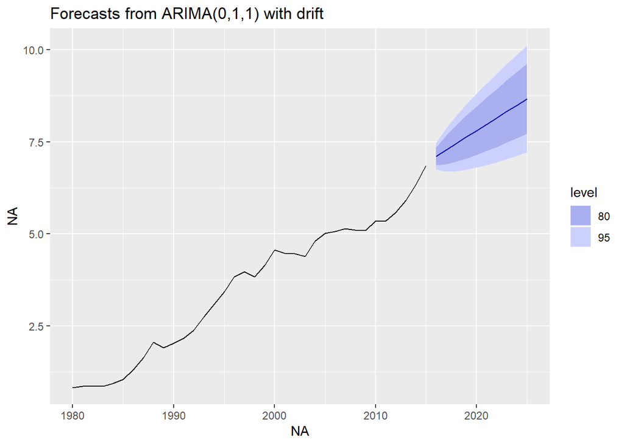

```r
# Plot forecasts of fit
fit %>% forecast(h = 10) %>% autoplot()
```

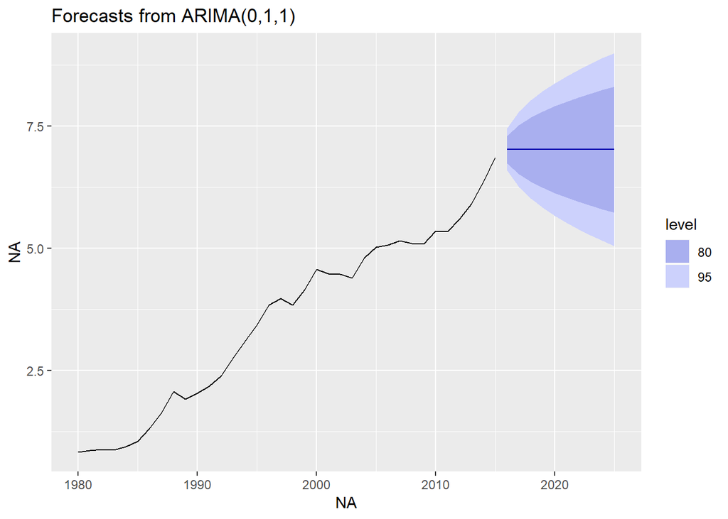

```r
# Plot forecasts from an ARIMA(0,1,1) model with no drift
austa %>% Arima(order = c(0,1,1), include.constant = FALSE) %>% forecast() %>% autoplot()
```

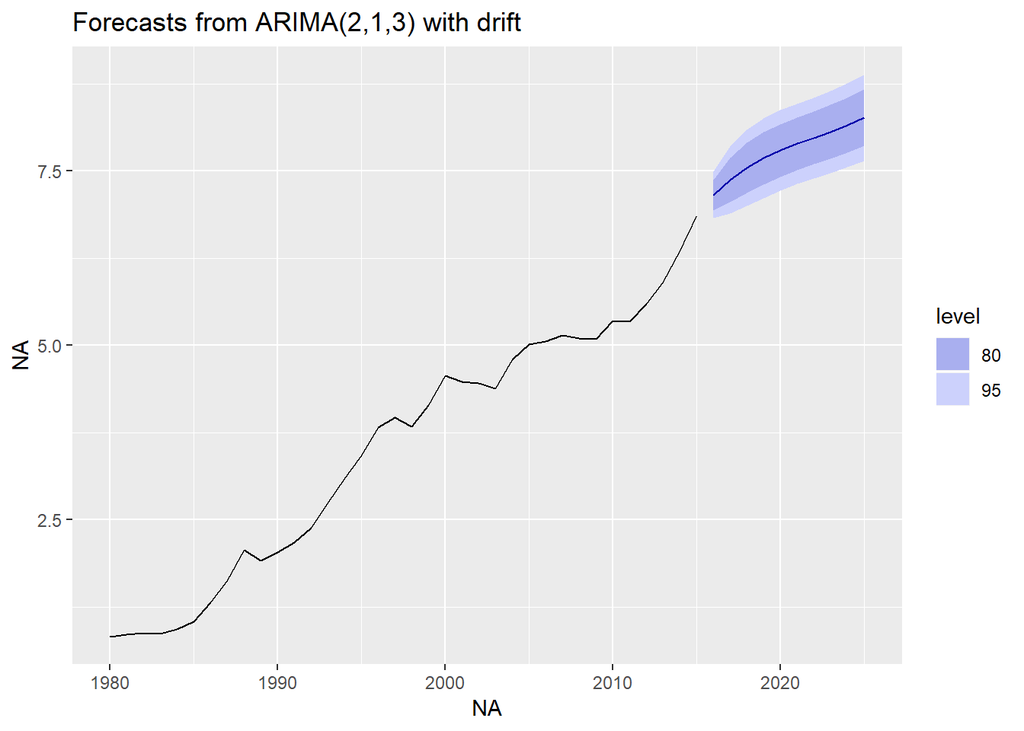

```r
# Plot forecasts from an ARIMA(2,1,3) model with drift
austa %>% Arima(order=c(2,1,3), include.constant=TRUE) %>% forecast() %>% autoplot()
```

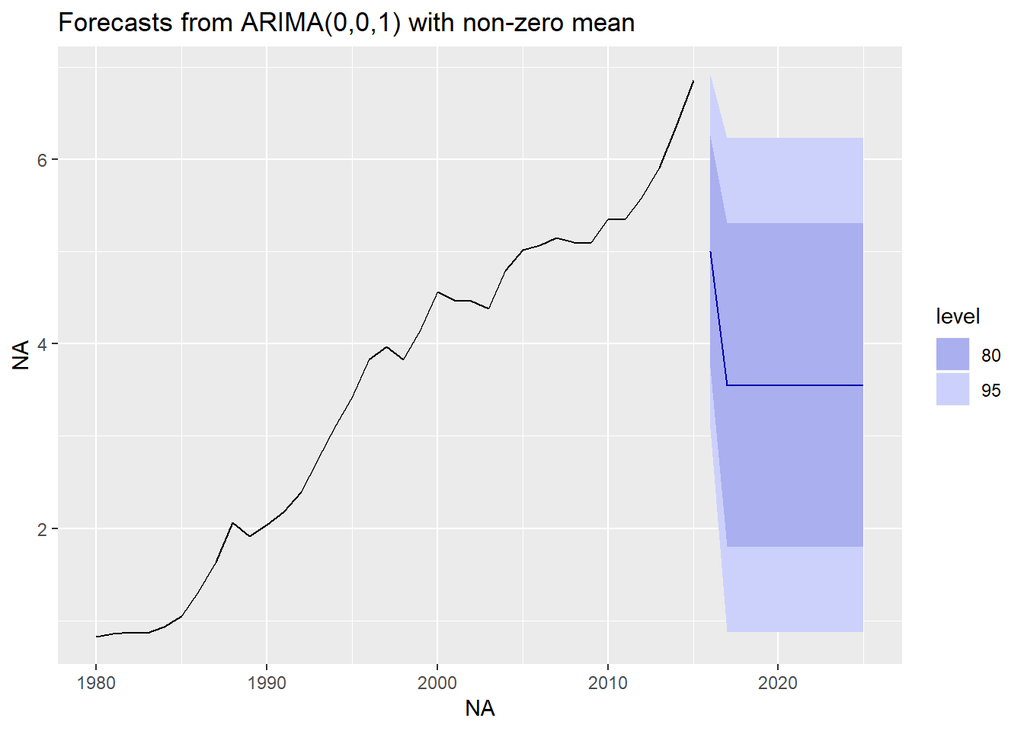

```r
# Plot forecasts from an ARIMA(0,0,1) model with a constant
austa %>% Arima(order=c(0,0,1), include.constant=TRUE) %>% forecast() %>% autoplot()
```

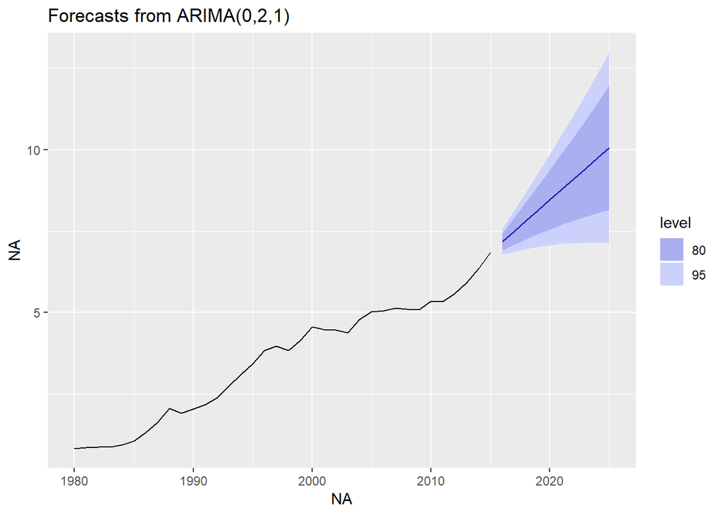

```r
# Plot forecasts from an ARIMA(0,2,1) model with no constant
austa %>% Arima(order=c(0,2,1), include.constant=FALSE) %>% forecast() %>% autoplot()
```

The AICc statistic is useful for selecting between models in the same class. For example, you can use it to select an ETS model or to select an ARIMA model. However, you cannot use it to compare ETS and ARIMA models because they are in different model classes. Instead, you can use time series cross-validation to compare an ARIMA model and an ETS model on the austa data. Because tsCV() requires functions that return forecast objects, you will set up some simple functions that fit the models and return the forecasts. The arguments of tsCV() are a time series, forecast function, and forecast horizon h.

```r
# Set up forecast functions for ETS and ARIMA models
fets <- function(x, h) {
  forecast(ets(x), h = h)
}
farima <- function(x, h) {
  forecast(auto.arima(x), h = h)
}

# Compute CV errors for ETS as e1
e1 <- tsCV(austa, fets, 1)

# Compute CV errors for ARIMA as e2
e2 <- tsCV(austa, farima, 1)

# Find MSE of each model class
mean(e1^2, na.rm=TRUE)
```

```
## [1] 0.05623684
```

```r
mean(e2^2, na.rm=TRUE)
```

```
## [1] 0.04336277
```

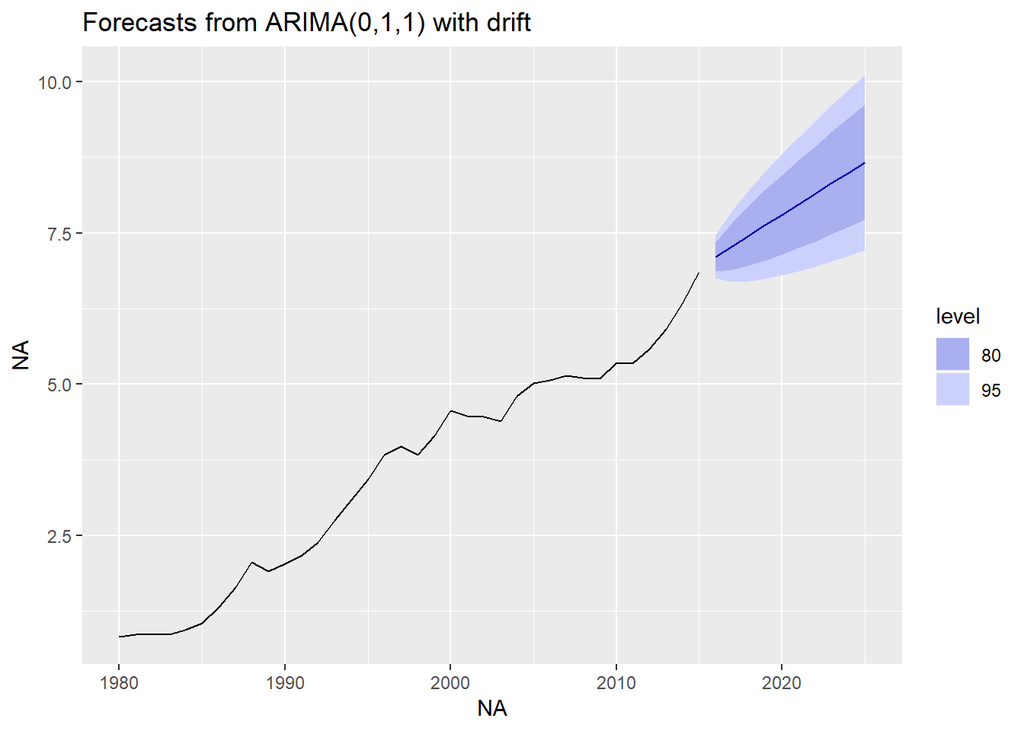

```r
# Plot 10-year forecasts using the best model class
austa %>% farima(h=10) %>% autoplot()
```

### Seasonal ARIMA models

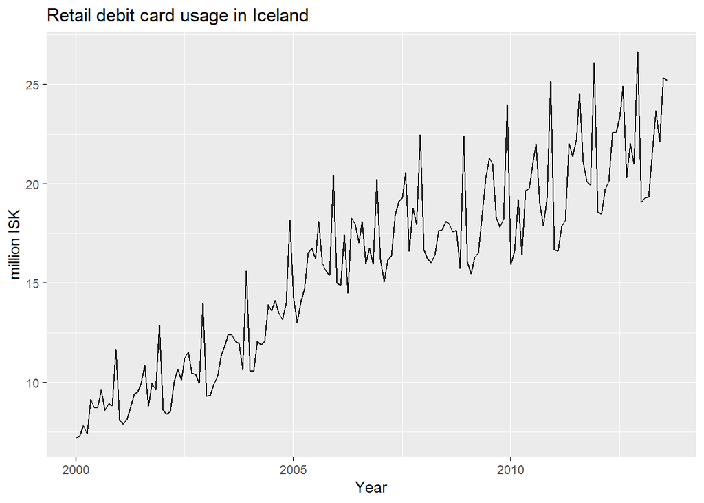

```r
# Seasonal arima with auto.arima()
autoplot(debitcards) +
  xlab("Year") +
  ylab("million ISK") +
  ggtitle("Retail debit card usage in Iceland")
```

```r
# Increasing variation -> Box-Cox
lmd <- BoxCox.lambda(debitcards)
# Use auto.arima to fit seasonal model
fit <- auto.arima(debitcards, lambda = lmd)
fit
```

```
## Series: debitcards
## ARIMA(0,1,2)(0,1,1)[12]
## Box Cox transformation: lambda= 0.09078485
##
## Coefficients:
##           ma1     ma2     sma1
##       -0.8221  0.2106  -0.8311
## s.e.   0.0854  0.0948   0.1136
##
## sigma^2 estimated as 0.003878:  log likelihood=199.12
## AIC=-390.25   AICc=-389.97   BIC=-378.18
```

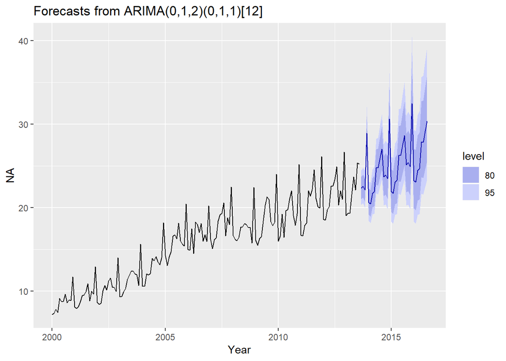

```r
# Forecasting and plotting
fit %>%
  forecast(h =36) %>%
  autoplot() + xlab("Year")
```

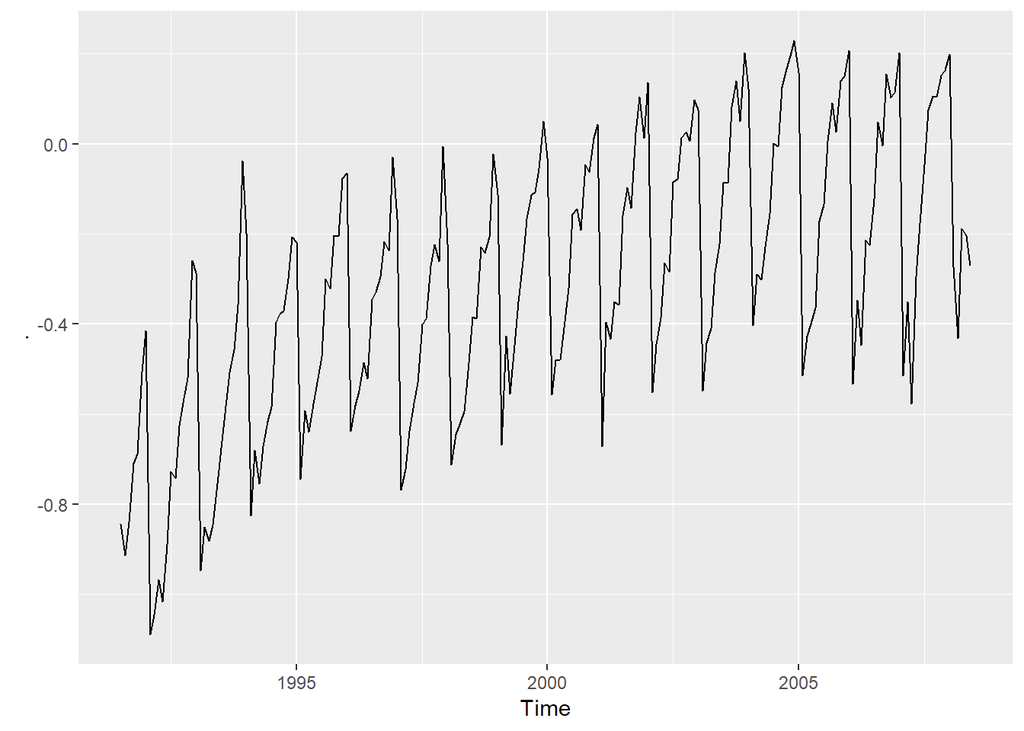

```r
### h02 data ###
# Check that the logged h02 data have stable variance
h02 %>% log() %>% autoplot()
```

```r
# Fit a seasonal ARIMA model to h02 with lambda = 0
fit <- auto.arima(h02, lambda=0)

# Summarize the fitted model
summary(fit)
```

```
## Series: h02
## ARIMA(2,1,1)(0,1,2)[12]
## Box Cox transformation: lambda= 0
##
## Coefficients:
##           ar1      ar2     ma1     sma1     sma2
##       -1.1358  -0.5753  0.3683  -0.5318  -0.1817
## s.e.   0.1608   0.0965  0.1884   0.0838   0.0881
##
## sigma^2 estimated as 0.004278:  log likelihood=248.25
## AIC=-484.51   AICc=-484.05   BIC=-465
##
## Training set error measures:
##                        ME      RMSE        MAE        MPE     MAPE
## Training set -0.003931805 0.0501571 0.03629816 -0.5323365 4.611253
##                   MASE         ACF1
## Training set 0.5987988 -0.003740267
```

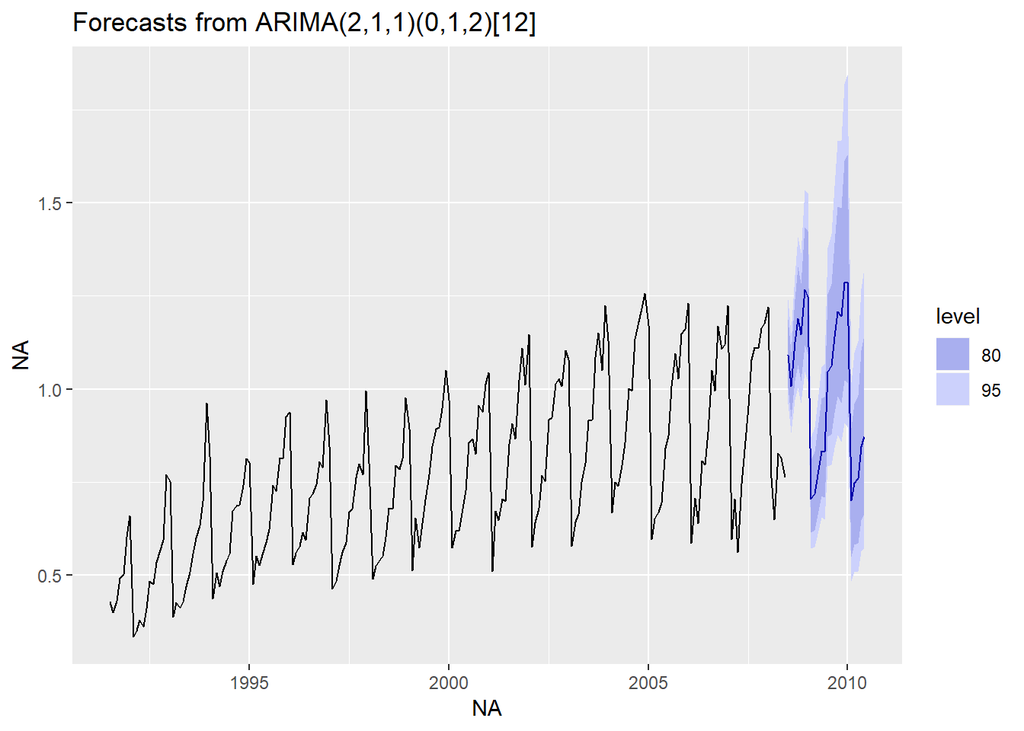

```r
# Record the amount of lag-1 differencing and seasonal differencing used
d <- 1
D <- 1

# Plot 2-year forecasts
fit %>% forecast(h=24) %>% autoplot()
```

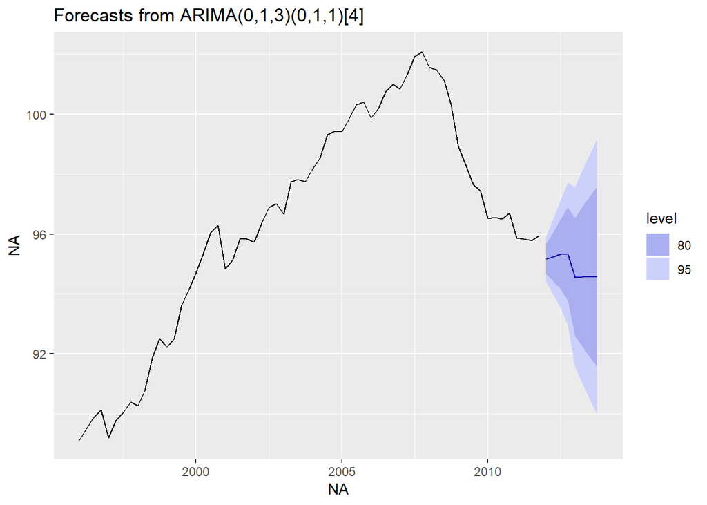

```r
### euretail ###
# Find an ARIMA model for euretail
fit1 <- auto.arima(euretail)

# Don't use a stepwise search
fit2 <- auto.arima(euretail, stepwise = FALSE)

# AICc of better model
AICc <- 68.39

# Compute 2-year forecasts from better model
fit2 %>% forecast(h=8) %>% autoplot()
```

Comparing auto.arima() and ets() on seasonal data.

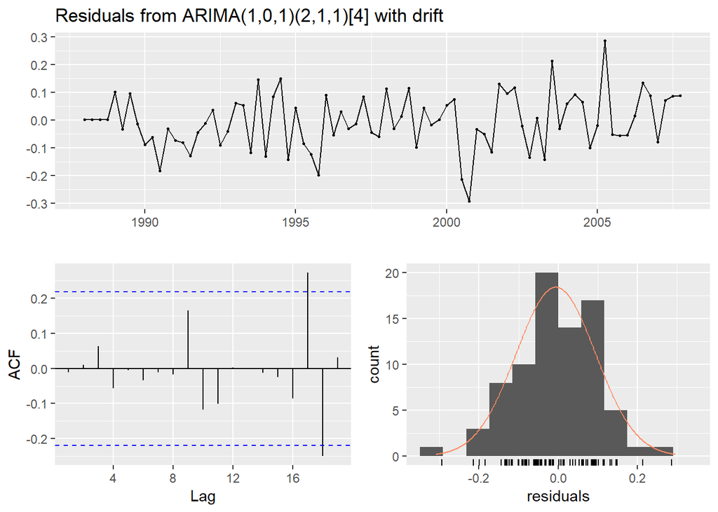

```
##
##  Ljung-Box test
##
## data:  Residuals from ARIMA(1,0,1)(2,1,1)[4] with drift
## Q* = 3.3058, df = 3, p-value = 0.3468
##
## Model df: 6.   Total lags used: 9
```

```r
# Use 20 years of the qcement data beginning in 1988
train <- window(qcement, start = c(1988,1), end = c(2007,4))

# Fit an ARIMA and an ETS model to the training data
fit1 <- auto.arima(train)
fit2 <- ets(train)

# Check that both models have white noise residuals
checkresiduals(fit1)
```

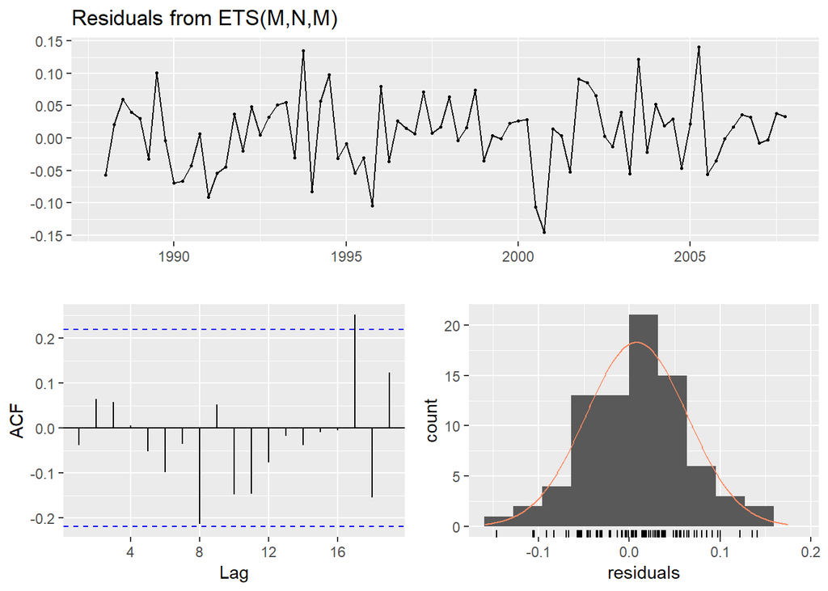

```
##
##  Ljung-Box test
##
## data:  Residuals from ETS(M,N,M)
## Q* = 6.3457, df = 3, p-value = 0.09595
##
## Model df: 6.   Total lags used: 9
```

```r
checkresiduals(fit2)
```

```r
# Produce forecasts for each model
fc1 <- forecast(fit1, h = 25)
fc2 <- forecast(fit2, h = 25)

# Use accuracy() to find better model based on RMSE
accuracy(fc1, qcement)
```

```
##                        ME      RMSE        MAE        MPE     MAPE
## Training set -0.006205705 0.1001195 0.07988903 -0.6704455 4.372443
## Test set     -0.158835253 0.1996098 0.16882205 -7.3332836 7.719241
##                   MASE        ACF1 Theil's U
## Training set 0.5458078 -0.01133907        NA
## Test set     1.1534049  0.29170452 0.7282225
```

```r
accuracy(fc2, qcement)
```

```
##                       ME      RMSE        MAE        MPE     MAPE
## Training set  0.01406512 0.1022079 0.07958478  0.4938163 4.371823
## Test set     -0.13495515 0.1838791 0.15395141 -6.2508975 6.986077
##                   MASE        ACF1 Theil's U
## Training set 0.5437292 -0.03346295        NA
## Test set     1.0518075  0.53438371  0.680556
```

```r
bettermodel <- fit2
```